# Risk Factor Analysis

## Outcome Variable

**Outcome Variable:** wasted

## Predictor Variables

**Intervention Variable:** hdlvry

**Adjustment Set:**

- arm
- sex
- W_mage
- meducyrs
- W_nrooms
- brthmon
- W_parity
- impsan
- delta_W_mage
- delta_meducyrs
- delta_W_nrooms
- delta_brthmon
- delta_W_parity
- delta_impsan

## Stratifying Variables

The analysis was stratified on these variable(s):

- agecat
- studyid
- country

## Data Summary

| agecat | studyid | country | hdlvry | wasted | n_cell | n |
| --- | --- | --- | --- | --- | --- | --- |
| Birth | ki1000108-CMC-V-BCS-2002 | INDIA | 0 | 0 | 74 | 88 |
| Birth | ki1000108-CMC-V-BCS-2002 | INDIA | 0 | 1 | 12 | 88 |
| Birth | ki1000108-CMC-V-BCS-2002 | INDIA | 1 | 0 | 0 | 88 |
| Birth | ki1000108-CMC-V-BCS-2002 | INDIA | 1 | 1 | 2 | 88 |
| Birth | ki1000108-IRC | INDIA | 0 | 0 | 249 | 343 |
| Birth | ki1000108-IRC | INDIA | 0 | 1 | 88 | 343 |
| Birth | ki1000108-IRC | INDIA | 1 | 0 | 2 | 343 |
| Birth | ki1000108-IRC | INDIA | 1 | 1 | 4 | 343 |
| Birth | ki1000109-EE | PAKISTAN | 0 | 0 | 1 | 1 |
| Birth | ki1000109-EE | PAKISTAN | 0 | 1 | 0 | 1 |
| Birth | ki1000109-EE | PAKISTAN | 1 | 0 | 0 | 1 |
| Birth | ki1000109-EE | PAKISTAN | 1 | 1 | 0 | 1 |
| Birth | ki1000304b-SAS-CompFeed | INDIA | 0 | 0 | 5 | 160 |
| Birth | ki1000304b-SAS-CompFeed | INDIA | 0 | 1 | 1 | 160 |
| Birth | ki1000304b-SAS-CompFeed | INDIA | 1 | 0 | 144 | 160 |
| Birth | ki1000304b-SAS-CompFeed | INDIA | 1 | 1 | 10 | 160 |
| Birth | ki1017093c-NIH-Crypto | BANGLADESH | 0 | 0 | 16 | 23 |
| Birth | ki1017093c-NIH-Crypto | BANGLADESH | 0 | 1 | 3 | 23 |
| Birth | ki1017093c-NIH-Crypto | BANGLADESH | 1 | 0 | 4 | 23 |
| Birth | ki1017093c-NIH-Crypto | BANGLADESH | 1 | 1 | 0 | 23 |
| Birth | ki1135781-COHORTS | INDIA | 0 | 0 | 2284 | 4389 |
| Birth | ki1135781-COHORTS | INDIA | 0 | 1 | 479 | 4389 |
| Birth | ki1135781-COHORTS | INDIA | 1 | 0 | 1344 | 4389 |
| Birth | ki1135781-COHORTS | INDIA | 1 | 1 | 282 | 4389 |
| Birth | kiGH5241-JiVitA-3 | BANGLADESH | 0 | 0 | 8 | 263 |
| Birth | kiGH5241-JiVitA-3 | BANGLADESH | 0 | 1 | 0 | 263 |
| Birth | kiGH5241-JiVitA-3 | BANGLADESH | 1 | 0 | 226 | 263 |
| Birth | kiGH5241-JiVitA-3 | BANGLADESH | 1 | 1 | 29 | 263 |
| Birth | kiGH5241-JiVitA-4 | BANGLADESH | 0 | 0 | 41 | 681 |
| Birth | kiGH5241-JiVitA-4 | BANGLADESH | 0 | 1 | 2 | 681 |

[output cut: 86 more lines]

The following strata were considered:

- agecat: 24 months, studyid: ki1000108-CMC-V-BCS-2002, country: INDIA
- agecat: 24 months, studyid: ki1000108-IRC, country: INDIA
- agecat: 24 months, studyid: ki1017093b-PROVIDE, country: BANGLADESH
- agecat: 24 months, studyid: ki1017093c-NIH-Crypto, country: BANGLADESH
- agecat: 24 months, studyid: ki1066203-TanzaniaChild2, country: TANZANIA, UNITED REPUBLIC OF
- agecat: 24 months, studyid: ki1113344-GMS-Nepal, country: NEPAL
- agecat: 24 months, studyid: ki1135781-COHORTS, country: INDIA
- agecat: 24 months, studyid: kiGH5241-JiVitA-3, country: BANGLADESH
- agecat: 24 months, studyid: kiGH5241-JiVitA-4, country: BANGLADESH
- agecat: 6 months, studyid: ki1000108-CMC-V-BCS-2002, country: INDIA
- agecat: 6 months, studyid: ki1000108-IRC, country: INDIA
- agecat: 6 months, studyid: ki1000109-EE, country: PAKISTAN
- agecat: 6 months, studyid: ki1000304b-SAS-CompFeed, country: INDIA
- agecat: 6 months, studyid: ki1000304b-SAS-FoodSuppl, country: INDIA
- agecat: 6 months, studyid: ki1017093b-PROVIDE, country: BANGLADESH
- agecat: 6 months, studyid: ki1017093c-NIH-Crypto, country: BANGLADESH
- agecat: 6 months, studyid: ki1066203-TanzaniaChild2, country: TANZANIA, UNITED REPUBLIC OF
- agecat: 6 months, studyid: ki1113344-GMS-Nepal, country: NEPAL
- agecat: 6 months, studyid: ki1135781-COHORTS, country: INDIA
- agecat: 6 months, studyid: kiGH5241-JiVitA-3, country: BANGLADESH
- agecat: 6 months, studyid: kiGH5241-JiVitA-4, country: BANGLADESH
- agecat: Birth, studyid: ki1000108-CMC-V-BCS-2002, country: INDIA
- agecat: Birth, studyid: ki1000108-IRC, country: INDIA
- agecat: Birth, studyid: ki1000109-EE, country: PAKISTAN
- agecat: Birth, studyid: ki1000304b-SAS-CompFeed, country: INDIA
- agecat: Birth, studyid: ki1017093c-NIH-Crypto, country: BANGLADESH
- agecat: Birth, studyid: ki1135781-COHORTS, country: INDIA
- agecat: Birth, studyid: kiGH5241-JiVitA-3, country: BANGLADESH
- agecat: Birth, studyid: kiGH5241-JiVitA-4, country: BANGLADESH

### Dropped Strata

Some strata were dropped due to rare outcomes:

- agecat: Birth, studyid: ki1000108-CMC-V-BCS-2002, country: INDIA
- agecat: Birth, studyid: ki1000108-IRC, country: INDIA
- agecat: Birth, studyid: ki1000109-EE, country: PAKISTAN
- agecat: Birth, studyid: ki1000304b-SAS-CompFeed, country: INDIA
- agecat: Birth, studyid: ki1017093c-NIH-Crypto, country: BANGLADESH
- agecat: Birth, studyid: kiGH5241-JiVitA-3, country: BANGLADESH
- agecat: Birth, studyid: kiGH5241-JiVitA-4, country: BANGLADESH
- agecat: 6 months, studyid: ki1000108-CMC-V-BCS-2002, country: INDIA
- agecat: 6 months, studyid: ki1000108-IRC, country: INDIA
- agecat: 6 months, studyid: ki1017093b-PROVIDE, country: BANGLADESH
- agecat: 6 months, studyid: ki1066203-TanzaniaChild2, country: TANZANIA, UNITED REPUBLIC OF
- agecat: 6 months, studyid: kiGH5241-JiVitA-3, country: BANGLADESH
- agecat: 24 months, studyid: ki1000108-CMC-V-BCS-2002, country: INDIA
- agecat: 24 months, studyid: ki1000108-IRC, country: INDIA
- agecat: 24 months, studyid: ki1066203-TanzaniaChild2, country: TANZANIA, UNITED REPUBLIC OF

## Methods Detail

We’re interested in the causal parameters $E[Y_a]$ for all values of $a \in \mathcal{A}$. These parameters represent the mean outcome if, possibly contrary to fact, we intervened to set all units to have $A=a$. Under the randomization and positivity assumptions, these are identified by the statistical parameters $\psi_a=E_W[E_{Y|A,W}(Y|A=a,W)]$. In addition, we’re interested in the mean of $Y$, $E[Y]$ under no intervention (the observed mean). We will estimate these parameters by using SuperLearner to fit the relevant likelihood factors – $E_{Y|A,W}(Y|A=a,W)$ and $p(A=a|W)$, and then updating our likelihood fit using a joint TMLE.

For unadjusted analyses ($W=\{\}$), initial likelihoods were estimated using Lrnr_glm to estimate the simple $E(Y|A)$ and Lrnr_mean to estimate $p(A)$. For adjusted analyses, a small library containing Lrnr_glmnet, Lrnr_xgboost, and Lrnr_mean was used.

Having estimated these parameters, we will then use the delta method to estimate relative risks and attributable risks relative to a prespecified baseline level of $A$.

# Results Detail

## Results Plots

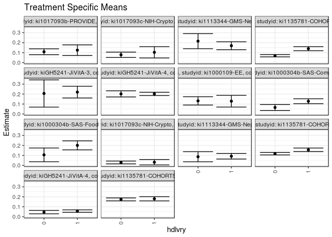

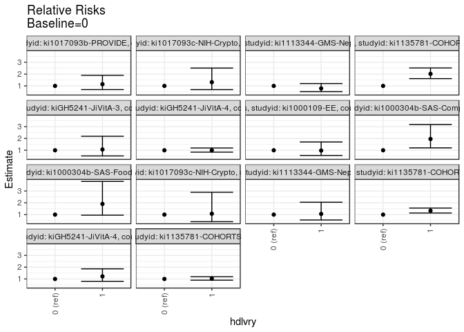

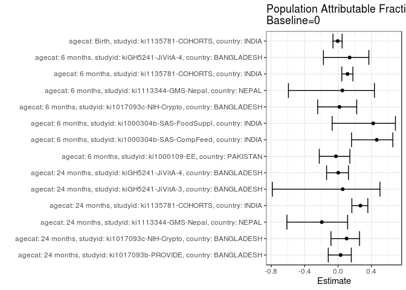

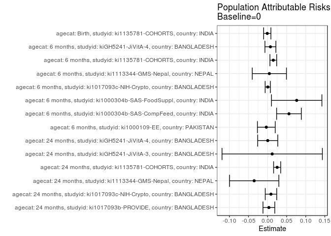

## Results Table

### Parameter: TSM

| agecat | studyid | country | intervention_level | baseline_level | estimate | ci_lower | ci_upper |
| --- | --- | --- | --- | --- | --- | --- | --- |
| Birth | ki1135781-COHORTS | INDIA | 0 | NA | 0.1741987 | 0.1593878 | 0.1890095 |
| Birth | ki1135781-COHORTS | INDIA | 1 | NA | 0.1801118 | 0.1591341 | 0.2010895 |
| 6 months | ki1000109-EE | PAKISTAN | 0 | NA | 0.1316380 | 0.0900521 | 0.1732240 |
| 6 months | ki1000109-EE | PAKISTAN | 1 | NA | 0.1284612 | 0.0697928 | 0.1871297 |
| 6 months | ki1000304b-SAS-CompFeed | INDIA | 0 | NA | 0.0652664 | 0.0351565 | 0.0953762 |
| 6 months | ki1000304b-SAS-CompFeed | INDIA | 1 | NA | 0.1276495 | 0.1029424 | 0.1523566 |
| 6 months | ki1000304b-SAS-FoodSuppl | INDIA | 0 | NA | 0.1052632 | 0.0361757 | 0.1743506 |
| 6 months | ki1000304b-SAS-FoodSuppl | INDIA | 1 | NA | 0.2006579 | 0.1555785 | 0.2457373 |
| 6 months | ki1017093c-NIH-Crypto | BANGLADESH | 0 | NA | 0.0288809 | 0.0149256 | 0.0428361 |
| 6 months | ki1017093c-NIH-Crypto | BANGLADESH | 1 | NA | 0.0310559 | 0.0042420 | 0.0578698 |
| 6 months | ki1113344-GMS-Nepal | NEPAL | 0 | NA | 0.0864190 | 0.0358478 | 0.1369903 |
| 6 months | ki1113344-GMS-Nepal | NEPAL | 1 | NA | 0.0914251 | 0.0631611 | 0.1196891 |
| 6 months | ki1135781-COHORTS | INDIA | 0 | NA | 0.1175128 | 0.1050984 | 0.1299272 |
| 6 months | ki1135781-COHORTS | INDIA | 1 | NA | 0.1561970 | 0.1381991 | 0.1741949 |
| 6 months | kiGH5241-JiVitA-4 | BANGLADESH | 0 | NA | 0.0462686 | 0.0292273 | 0.0633098 |
| 6 months | kiGH5241-JiVitA-4 | BANGLADESH | 1 | NA | 0.0564947 | 0.0441542 | 0.0688353 |
| 24 months | ki1017093b-PROVIDE | BANGLADESH | 0 | NA | 0.1090491 | 0.0796384 | 0.1384598 |
| 24 months | ki1017093b-PROVIDE | BANGLADESH | 1 | NA | 0.1247965 | 0.0713682 | 0.1782247 |
| 24 months | ki1017093c-NIH-Crypto | BANGLADESH | 0 | NA | 0.0786228 | 0.0517545 | 0.1054911 |
| 24 months | ki1017093c-NIH-Crypto | BANGLADESH | 1 | NA | 0.1033372 | 0.0465851 | 0.1600892 |
| 24 months | ki1113344-GMS-Nepal | NEPAL | 0 | NA | 0.2153953 | 0.1396167 | 0.2911739 |
| 24 months | ki1113344-GMS-Nepal | NEPAL | 1 | NA | 0.1695136 | 0.1295990 | 0.2094283 |
| 24 months | ki1135781-COHORTS | INDIA | 0 | NA | 0.0691303 | 0.0575731 | 0.0806875 |
| 24 months | ki1135781-COHORTS | INDIA | 1 | NA | 0.1398377 | 0.1194105 | 0.1602650 |
| 24 months | kiGH5241-JiVitA-3 | BANGLADESH | 0 | NA | 0.2058824 | 0.0691344 | 0.3426304 |
| 24 months | kiGH5241-JiVitA-3 | BANGLADESH | 1 | NA | 0.2196078 | 0.1605007 | 0.2787149 |
| 24 months | kiGH5241-JiVitA-4 | BANGLADESH | 0 | NA | 0.2017134 | 0.1708103 | 0.2326166 |
| 24 months | kiGH5241-JiVitA-4 | BANGLADESH | 1 | NA | 0.2018043 | 0.1851634 | 0.2184452 |

### Parameter: E(Y)

| agecat | studyid | country | intervention_level | baseline_level | estimate | ci_lower | ci_upper |
| --- | --- | --- | --- | --- | --- | --- | --- |
| Birth | ki1135781-COHORTS | INDIA | NA | NA | 0.1733880 | 0.1621865 | 0.1845895 |
| 6 months | ki1000109-EE | PAKISTAN | NA | NA | 0.1283422 | 0.0943991 | 0.1622853 |
| 6 months | ki1000304b-SAS-CompFeed | INDIA | NA | NA | 0.1213235 | 0.0974115 | 0.1452356 |
| 6 months | ki1000304b-SAS-FoodSuppl | INDIA | NA | NA | 0.1815789 | 0.1427684 | 0.2203895 |
| 6 months | ki1017093c-NIH-Crypto | BANGLADESH | NA | NA | 0.0293706 | 0.0169860 | 0.0417552 |
| 6 months | ki1113344-GMS-Nepal | NEPAL | NA | NA | 0.0910816 | 0.0664930 | 0.1156701 |
| 6 months | ki1135781-COHORTS | INDIA | NA | NA | 0.1325096 | 0.1228094 | 0.1422097 |
| 6 months | kiGH5241-JiVitA-4 | BANGLADESH | NA | NA | 0.0536863 | 0.0440214 | 0.0633512 |
| 24 months | ki1017093b-PROVIDE | BANGLADESH | NA | NA | 0.1124567 | 0.0866788 | 0.1382347 |
| 24 months | ki1017093c-NIH-Crypto | BANGLADESH | NA | NA | 0.0875486 | 0.0630907 | 0.1120065 |
| 24 months | ki1113344-GMS-Nepal | NEPAL | NA | NA | 0.1802575 | 0.1453188 | 0.2151962 |
| 24 months | ki1135781-COHORTS | INDIA | NA | NA | 0.0942542 | 0.0846183 | 0.1038901 |
| 24 months | kiGH5241-JiVitA-3 | BANGLADESH | NA | NA | 0.2179931 | 0.1635507 | 0.2724354 |
| 24 months | kiGH5241-JiVitA-4 | BANGLADESH | NA | NA | 0.2021037 | 0.1874836 | 0.2167238 |

### Parameter: RR

| agecat | studyid | country | intervention_level | baseline_level | estimate | ci_lower | ci_upper |
| --- | --- | --- | --- | --- | --- | --- | --- |
| Birth | ki1135781-COHORTS | INDIA | 0 | 0 | 1.0000000 | 1.0000000 | 1.000000 |
| Birth | ki1135781-COHORTS | INDIA | 1 | 0 | 1.0339448 | 0.8952760 | 1.194092 |
| 6 months | ki1000109-EE | PAKISTAN | 0 | 0 | 1.0000000 | 1.0000000 | 1.000000 |
| 6 months | ki1000109-EE | PAKISTAN | 1 | 0 | 0.9758671 | 0.5591498 | 1.703151 |
| 6 months | ki1000304b-SAS-CompFeed | INDIA | 0 | 0 | 1.0000000 | 1.0000000 | 1.000000 |
| 6 months | ki1000304b-SAS-CompFeed | INDIA | 1 | 0 | 1.9558231 | 1.2026353 | 3.180718 |
| 6 months | ki1000304b-SAS-FoodSuppl | INDIA | 0 | 0 | 1.0000000 | 1.0000000 | 1.000000 |
| 6 months | ki1000304b-SAS-FoodSuppl | INDIA | 1 | 0 | 1.9062500 | 0.9525832 | 3.814668 |
| 6 months | ki1017093c-NIH-Crypto | BANGLADESH | 0 | 0 | 1.0000000 | 1.0000000 | 1.000000 |
| 6 months | ki1017093c-NIH-Crypto | BANGLADESH | 1 | 0 | 1.0753106 | 0.3997909 | 2.892244 |
| 6 months | ki1113344-GMS-Nepal | NEPAL | 0 | 0 | 1.0000000 | 1.0000000 | 1.000000 |
| 6 months | ki1113344-GMS-Nepal | NEPAL | 1 | 0 | 1.0579275 | 0.5454180 | 2.052024 |
| 6 months | ki1135781-COHORTS | INDIA | 0 | 0 | 1.0000000 | 1.0000000 | 1.000000 |
| 6 months | ki1135781-COHORTS | INDIA | 1 | 0 | 1.3291916 | 1.1369961 | 1.553875 |
| 6 months | kiGH5241-JiVitA-4 | BANGLADESH | 0 | 0 | 1.0000000 | 1.0000000 | 1.000000 |
| 6 months | kiGH5241-JiVitA-4 | BANGLADESH | 1 | 0 | 1.2210173 | 0.8016384 | 1.859795 |
| 24 months | ki1017093b-PROVIDE | BANGLADESH | 0 | 0 | 1.0000000 | 1.0000000 | 1.000000 |
| 24 months | ki1017093b-PROVIDE | BANGLADESH | 1 | 0 | 1.1444063 | 0.6895905 | 1.899194 |
| 24 months | ki1017093c-NIH-Crypto | BANGLADESH | 0 | 0 | 1.0000000 | 1.0000000 | 1.000000 |
| 24 months | ki1017093c-NIH-Crypto | BANGLADESH | 1 | 0 | 1.3143411 | 0.6870840 | 2.514238 |
| 24 months | ki1113344-GMS-Nepal | NEPAL | 0 | 0 | 1.0000000 | 1.0000000 | 1.000000 |
| 24 months | ki1113344-GMS-Nepal | NEPAL | 1 | 0 | 0.7869884 | 0.5150842 | 1.202426 |
| 24 months | ki1135781-COHORTS | INDIA | 0 | 0 | 1.0000000 | 1.0000000 | 1.000000 |
| 24 months | ki1135781-COHORTS | INDIA | 1 | 0 | 2.0228129 | 1.6206235 | 2.524814 |
| 24 months | kiGH5241-JiVitA-3 | BANGLADESH | 0 | 0 | 1.0000000 | 1.0000000 | 1.000000 |
| 24 months | kiGH5241-JiVitA-3 | BANGLADESH | 1 | 0 | 1.0666667 | 0.5204438 | 2.186168 |
| 24 months | kiGH5241-JiVitA-4 | BANGLADESH | 0 | 0 | 1.0000000 | 1.0000000 | 1.000000 |
| 24 months | kiGH5241-JiVitA-4 | BANGLADESH | 1 | 0 | 1.0004503 | 0.8393478 | 1.192475 |

### Parameter: PAR

| agecat | studyid | country | intervention_level | baseline_level | estimate | ci_lower | ci_upper |
| --- | --- | --- | --- | --- | --- | --- | --- |
| Birth | ki1135781-COHORTS | INDIA | 0 | NA | -0.0008106 | -0.0103242 | 0.0087029 |
| 6 months | ki1000109-EE | PAKISTAN | 0 | NA | -0.0032958 | -0.0266530 | 0.0200614 |
| 6 months | ki1000304b-SAS-CompFeed | INDIA | 0 | NA | 0.0560571 | 0.0236760 | 0.0884383 |
| 6 months | ki1000304b-SAS-FoodSuppl | INDIA | 0 | NA | 0.0763158 | 0.0102090 | 0.1424226 |
| 6 months | ki1017093c-NIH-Crypto | BANGLADESH | 0 | NA | 0.0004898 | -0.0063172 | 0.0072967 |
| 6 months | ki1113344-GMS-Nepal | NEPAL | 0 | NA | 0.0046626 | -0.0401721 | 0.0494972 |
| 6 months | ki1135781-COHORTS | INDIA | 0 | NA | 0.0149968 | 0.0061724 | 0.0238213 |
| 6 months | kiGH5241-JiVitA-4 | BANGLADESH | 0 | NA | 0.0074177 | -0.0069125 | 0.0217479 |
| 24 months | ki1017093b-PROVIDE | BANGLADESH | 0 | NA | 0.0034077 | -0.0120572 | 0.0188725 |
| 24 months | ki1017093c-NIH-Crypto | BANGLADESH | 0 | NA | 0.0089259 | -0.0061113 | 0.0239630 |
| 24 months | ki1113344-GMS-Nepal | NEPAL | 0 | NA | -0.0351378 | -0.0998050 | 0.0295294 |
| 24 months | ki1135781-COHORTS | INDIA | 0 | NA | 0.0251238 | 0.0158484 | 0.0343993 |
| 24 months | kiGH5241-JiVitA-3 | BANGLADESH | 0 | NA | 0.0121107 | -0.1194466 | 0.1436680 |
| 24 months | kiGH5241-JiVitA-4 | BANGLADESH | 0 | NA | 0.0003902 | -0.0259476 | 0.0267281 |

### Parameter: PAF

| agecat | studyid | country | intervention_level | baseline_level | estimate | ci_lower | ci_upper |
| --- | --- | --- | --- | --- | --- | --- | --- |
| Birth | ki1135781-COHORTS | INDIA | 0 | NA | -0.0046753 | -0.0610657 | 0.0487183 |
| 6 months | ki1000109-EE | PAKISTAN | 0 | NA | -0.0256797 | -0.2248053 | 0.1410725 |
| 6 months | ki1000304b-SAS-CompFeed | INDIA | 0 | NA | 0.4620467 | 0.1611255 | 0.6550214 |
| 6 months | ki1000304b-SAS-FoodSuppl | INDIA | 0 | NA | 0.4202899 | -0.0708179 | 0.6861615 |
| 6 months | ki1017093c-NIH-Crypto | BANGLADESH | 0 | NA | 0.0166753 | -0.2445475 | 0.2230690 |
| 6 months | ki1113344-GMS-Nepal | NEPAL | 0 | NA | 0.0511910 | -0.5937396 | 0.4351408 |
| 6 months | ki1135781-COHORTS | INDIA | 0 | NA | 0.1131753 | 0.0443928 | 0.1770070 |
| 6 months | kiGH5241-JiVitA-4 | BANGLADESH | 0 | NA | 0.1381678 | -0.1752686 | 0.3680128 |
| 24 months | ki1017093b-PROVIDE | BANGLADESH | 0 | NA | 0.0303020 | -0.1172593 | 0.1583741 |
| 24 months | ki1017093c-NIH-Crypto | BANGLADESH | 0 | NA | 0.1019531 | -0.0853800 | 0.2569531 |
| 24 months | ki1113344-GMS-Nepal | NEPAL | 0 | NA | -0.1949312 | -0.6122011 | 0.1143410 |
| 24 months | ki1135781-COHORTS | INDIA | 0 | NA | 0.2665541 | 0.1648741 | 0.3558542 |
| 24 months | kiGH5241-JiVitA-3 | BANGLADESH | 0 | NA | 0.0555556 | -0.7867351 | 0.5007792 |
| 24 months | kiGH5241-JiVitA-4 | BANGLADESH | 0 | NA | 0.0019309 | -0.1372881 | 0.1241076 |